# EyzaguirreVenegas_MoranGarciaQuijada_HerreraCorrales_TMFinalAsignment

José Manuel Eyzaguirre Venegas, Carlos Morán García Quijada, Luis Miguel Herrera Corrales

2026-04-01

## 1 Decoding the Crown: An analysis of King Felipe VI’s speeches (2014-2024).

Words reflect reality. Moreover, when spoken by an influential leader, they can reveal historical shifts, social climates, and the impact of important crises. In the very act of believing that words have the capacity to reveal these hidden patterns, this work analyzes the Christmas speeches of King Felipe VI from 2014 to 2024, a decade marked by coronation, the Catalan conflict, political fragmentation, and the pandemic. Internationally, this period shifted from stability to a framework of war and decay in multilateralism.

Assuming that language evolves alongside reality, this study relies on computational methods, specifically sentiment analysis and topic modeling, to inspect these discourses. As annual summaries from the Spanish Head of State that promote civic values, these speeches may serve as a vital proxy for understanding the changing conceptions of the decade’s turbulent context, and are conceived as a well-built example of behaviors, ideas, and sentiments marking the time span selected.

## 2 Data loading, pre-processing and n-gram analysis.

That said, the following code is intended to download, inspect, split, and apply the techniques mentioned to demonstrate that words are much more than just a concatenation of letters in a specified order. As they carry meanings, they are, per se, a translation of a view in reality, which is, per se, dynamic and changeable. In the first step of that coding, the following chunk loads all discourses collected manually from the Casa Real archive accessible [here](https://www.casareal.es/ES/Actividades/Paginas/actividades_discursos-resultado.aspx?TA=D&FI=Desde&C=14).

```r
# --- 1. SETUP & REQUIREMENTS ---
# Package installation is commented out as per assignment rules.
# install.packages("readtext")
# install.packages(quanteda)
# install.package(tidyverse) as we are going to use several packages within tidyverse.   Otherwise can be done install.packages(c("dplyr", "stringr"))
library(readtext)
library(tidyverse)
library(quanteda)

# --- 2. DATA INGESTION ---
# We use readtext to batch-load all .txt files from the speeches subfolder.
# The pattern "*.txt" ensures we capture all years from 2014 to 2024.
raw_speeches <- readtext("data/speeches/*.txt")

# --- 3. CORPUS CONSTRUCTION ---
# Creating a quanteda corpus object for downstream text mining.
speech_corpus <- corpus(raw_speeches)

# --- 4. METADATA EXTRACTION (NON-OBVIOUS) ---
# The filenames are formatted as "YYYY_speech.txt".
# We use a regular expression (regex) to extract the first 4 digits
# and assign them to a document variable called 'Year'.
docvars(speech_corpus, "Year") <- as.numeric(gsub("^(\\d{4}).*", "\\1", docnames(speech_corpus)))

# --- 5. VERIFICATION ---
# Checking that all 11 documents are loaded correctly.
print(paste("Total speeches loaded:", ndoc(speech_corpus)))
```

```
## [1] "Total speeches loaded: 11"
```

```r
head(docvars(speech_corpus))
```

```
##   Year
## 1 2014
## 2 2015
## 3 2016
## 4 2017
## 5 2018
## 6 2019
```

## 3 Sentiment Analysis on King Felipe´s speeches.

Words are repositories of meaning, and as long as reflect reality they carry the weight of emotions from where they flourish. When talking about the speeches given to a crowd so inmense and diverse as a country citizenship, sentiments are of great interest, as they can reveal the nuances of context unknown when analyzing words as such. Hence, by analyzing the sentiments behind the speeches given the varied amount and intensity of events related, a more precise image of whether these times were conceived by the main political figure of Spain as positive or negative based on his speeches can be conceived as a proxy for the general sentiment of the country in that specific time.

That said, some minor changes are needed from previous works. As sentiment are best performed when an holistic approach is selected, speeches need now to be splitted by paragraphs, rather than by speech. Although speeches can, per se, show some positive or negative meaning when appplying sentiment analysis, paragraphs are a most suitable, precise and rigorous selection of meaning, as it opens the windows for clearer contextual understanding. Hence, with only 11 speeches, working at the paragraph level provides a more granular view of how sentiment fluctuates within and across years. In that light, each paragraph receives a unique identifier combining the year and its position within the speech in the following chunk.

```r
# --- 0. LIBRARIES ---
# We use tidytext to bridge quanteda and the tidyverse
library(tidytext)

# --- 1. PARAGRAPH SEGMENTATION (SOLVED) ---
# We use 'convert' to transform the quanteda corpus into a standard data frame.
# This is more robust than tidy() for corpus objects.

speeches_paragraphs <- speech_corpus %>%
  # 1. Convert the corpus into a data frame (keeps your 'Year' docvar)
  quanteda::convert(to = "data.frame") %>%
  # 2. Split the 'text' column into a list of paragraphs using double newlines
  mutate(paragraph = str_split(text, "\\n\\n")) %>%
  # 3. Expand the list so each paragraph gets its own row
  unnest(paragraph) %>%
  # 4. Clean whitespace and remove empty strings
  mutate(paragraph = str_trim(paragraph)) %>%
  filter(paragraph != "") %>%
  # 5. Create a unique ID for each paragraph using your metadata 'Year'
  group_by(Year) %>%
  mutate(paragraph_id = paste0(Year, "_par", row_number())) %>%
  ungroup()

# --- 2. VERIFICATION ---
# Verify the columns 'Year', 'paragraph_id', and 'paragraph' exist.
speeches_paragraphs %>%
  select(Year, paragraph_id, paragraph) %>%
  head()
```

```
## # A tibble: 6 × 3
##    Year paragraph_id paragraph
##   <dbl> <chr>        <chr>
## 1  2014 2014_par1    Buenas noches.
## 2  2014 2014_par2    Quiero, en primer lugar, daros las gracias por abrirme vue…
## 3  2014 2014_par3    Hoy quiero estar a vuestro lado para compartir  —en el pri…
## 4  2014 2014_par4    Estamos viviendo tiempos complejos y difíciles para muchos…
## 5  2014 2014_par5    Los problemas que he mencionado han dado lugar a una seria…
## 6  2014 2014_par6    El pasado mes de octubre afirmé en Asturias que necesitába…
```

Once done this, it is needed to filter for stopwords and words with few if any informational value. Although a list of stopwords have been used from quanteda in previous steps, it is now updated with some other custom stopwords that in eyes of this team of researcher are conceived as of limited informational value for this specific task. That said, the following chunk replicates this process.

```r
# --- CUSTOM STOPWORD LEXICON ---
# This block defines a comprehensive exclusion list to filter out "institutional noise."
# It combines standard Spanish language stops with terms specific to Royal addresses.

# 1. Standard Spanish Stopwords
# Loading the base dictionary from the quanteda package.
spanish_stops <- data.frame(word = quanteda::stopwords("spanish"))

# 2. Discourse-Specific Exclusions
# These terms are common to every speech and are categorized by their rhetorical function.
custom_stops <- data.frame(word = c(
  # National identity terms (High frequency but low thematic variance)
  "españa", "español", "española", "españoles", "españolas",
  "país", "nación", "nacional", "nacionales",

  # Christmas address formulas and Royal titles
  "navidad", "feliz", "majestades", "rey", "reina", "felipe",
  "nochebuena", "navideño",

  # Generic temporal and spatial references
  "año", "años", "hoy", "momento", "tiempo", "día", "días",

  # High-frequency discourse verbs and fillers
  "quiero", "decir", "hacer", "puede", "debemos", "quiere",
  "sé", "creo", "voy", "vamos", "así", "aquí", "ahora",

  # Common modifiers and quantifiers
  "todos", "todo", "toda", "todas", "bien", "gran", "grande",
  "más", "muy", "tan", "siempre"
))

# 3. Master Stopword Vector
# Combining both data frames into a single unique character vector for later use.
final_stopwords <- unique(c(spanish_stops$word, custom_stops$word))
```

Given the stopwords are now merged and speeches are split into paragraphs, it is time to unnnest and tokenize by word, that are still conceived as the minimum informational valuable unit of text analyzed. Although this has been done in previous steps, for this specific part of the project, it is repeated, under the need to filter by the customized stopwords list. In this specific case, unnest_tokens is preferred for being faster and tidier than the quanteda option.

```r
# --- 1. TIDY TEXT TOKENIZATION ---
# We break down the segmented paragraphs into individual words (tokens).
# This creates a one-row-per-term structure while maintaining metadata (Year, paragraph_id).

tidy_speeches <- speeches_paragraphs %>%
  # Tokenize the 'paragraph' column into individual words
  unnest_tokens(word, paragraph) %>%
  # Apply the standard Spanish stopword filter
  anti_join(spanish_stops, by = "word") %>%
  # Apply our custom Royal discourse exclusion list
  anti_join(custom_stops, by = "word")

# --- 2. PREVIEW RESULTS ---
# Verifying the structure: we should see the Year, the unique paragraph ID, and the cleaned word.
head(tidy_speeches)
```

```
## # A tibble: 6 × 5
##   doc_id          text                                   Year paragraph_id word
##   <chr>           <chr>                                 <dbl> <chr>        <chr>
## 1 2014_speech.txt "Buenas noches.\n\nQuiero, en primer…  2014 2014_par1    buen…
## 2 2014_speech.txt "Buenas noches.\n\nQuiero, en primer…  2014 2014_par1    noch…
## 3 2014_speech.txt "Buenas noches.\n\nQuiero, en primer…  2014 2014_par2    prim…
## 4 2014_speech.txt "Buenas noches.\n\nQuiero, en primer…  2014 2014_par2    lugar
## 5 2014_speech.txt "Buenas noches.\n\nQuiero, en primer…  2014 2014_par2    daros
## 6 2014_speech.txt "Buenas noches.\n\nQuiero, en primer…  2014 2014_par2    grac…
```

Once the data is cleaned, filtered and tokenized, it is crucial to select a lexicon over the which sentiment analysis is run. Hence, it is needed to both select and inspect the tool this analysis rely on, in order to adapt it to the language of the speeches and overcome some specific bias of the lexicon selected. That said, the course materials introduce three English-language sentiment lexicons: AFINN, Bing, and NRC. Since the corpus is in Spanish, it is required a lexicon that has been translated to this language. The NRC Word-Emotion Association Lexicon (Mohammad & Turney, 2013) is the only one among the three that offers official translations in over 100 languages, including Spanish. This team of researchers access it through the `syuzhet` package, following the methodology described by Isasi (2021) for sentiment analysis in Spanish with R.

The NRC lexicon is particularly well suited for this analysis because it provides both polarity labels (positive and negative) and eight discrete emotion categories (anger, anticipation, disgust, fear, joy, sadness, surprise, and trust). This dual structure allows to go beyond simple positive-negative classification and examine the emotional profile of the speeches in greater depth, which is especially relevant for political discourse that often blends hopeful and cautionary tones.

It should be noted, however, that the Spanish version of the NRC lexicon is the result of automatic translation from English, and the sentiment values assigned to each word were determined through surveys with predominantly English-speaking participants (Isasi, 2021). This introduces a potential cultural and linguistic bias that must be considered when interpreting the results. Additionally, dictionary-based approaches cannot capture negation or irony, meaning that phrases like “no estoy feliz” would still contribute a positive score through the word “feliz”.

```r
# ---1. LIBRARIES ----
# isntall.packages("syuzhet") if not done before
library(syuzhet )

# --- 2. LOADING THE NRC SPANISH EMOTION LEXICON ---
# We fetch the NRC Word-Emotion Association Lexicon translated into Spanish.
# This allows us to map the King's vocabulary to specific emotional states.

# Fetching the dictionary
nrc_es <- get_sentiment_dictionary(dictionary = "nrc", language = "spanish")

# 2.1. Inspecting the Emotional Mappings
# We view the first 10 entries to understand the structure: 'word', 'sentiment', and 'score'.
head(nrc_es, 10)
```

```
##       lang       word sentiment value
## 1  spanish       abba  positive     1
## 2  spanish  capacidad  positive     1
## 3  spanish     citada  positive     1
## 4  spanish   absoluto  positive     1
## 5  spanish absolución  positive     1
## 6  spanish  absorbido  positive     1
## 7  spanish abundancia  positive     1
## 8  spanish  abundante  positive     1
## 9  spanish  académico  positive     1
## 10 spanish   academia  positive     1
```

```r
# 2.2. Technical Validation
# We check the unique sentiment categories available in the Spanish NRC.
unique(nrc_es$sentiment)
```

```
##  [1] "positive"     "negative"     "anger"        "anticipation" "disgust"
##  [6] "fear"         "joy"          "sadness"      "surprise"     "trust"
```

As it is shown, lexicon loads correctly with four columns: lang, word, sentiment, and value. Each row represents a single word-sentiment association, where value = 1 indicates that the word is associated with that category. Since the NRC is a multilabel lexicon, the same word can appear multiple times under different sentiment or emotion labels, for example, a word like “abandono” may be tagged as both “negative” and “sadness”

That said, Bbefore applying the lexicon to the corpus, it is worth understanding its composition. Thus, it is time to examine how many words are classified under each sentiment and emotion category, and whether there is any imbalance between positive and negative terms. As discussed in the course materials, lexicon bias is a known risk in dictionary-based sentiment analysis: if a lexicon contains significantly more negative than positive words, it may skew results towards negativity regardless of the actual text content

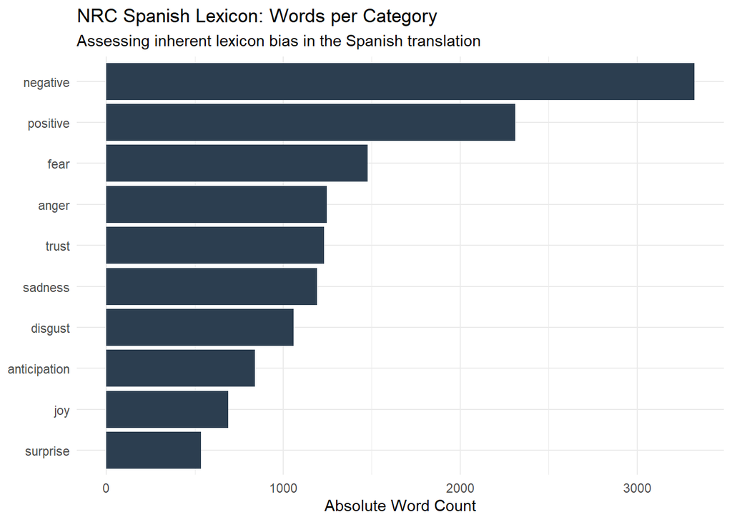

```r
# --- 1. PREPARING THE NRC EMOTION DICTIONARY ---
# We align the dictionary column names with the tidytext 'word' format.
# This ensures a seamless inner_join() with our 'tidy_speeches' object.

nrc_es <- nrc_es %>%
  rename(sentiment = sentiment, word = word)

# --- 2. LEXICON BIAS CHECK (TECHNICAL REQUIREMENT) ---
# We visualize the distribution of words across the 10 NRC categories.
# This reveals if the lexicon is naturally weighted toward certain emotions.

nrc_es %>%
  count(sentiment, sort = TRUE) %>%
  ggplot(aes(x = reorder(sentiment, n), y = n)) +
  geom_col(fill = "#2c3e50") +
  coord_flip() +
  labs(title = "NRC Spanish Lexicon: Words per Category",
       subtitle = "Assessing inherent lexicon bias in the Spanish translation",
       x = NULL, y = "Absolute Word Count") +
  theme_minimal()
```

```r
# --- 3. POLARITY BALANCE TEST ---
# A specific check to compare the ratio of 'positive' vs 'negative' entries.
# This helps us calibrate our final interpretation of the King's speeches.

nrc_polarity_check <- nrc_es %>%
  filter(sentiment %in% c("positive", "negative")) %>%
  count(sentiment)

print(nrc_polarity_check)
```

```
##   sentiment    n
## 1  negative 3324
## 2  positive 2312
```

As it is shown, the lexicon exhibits a clear negative bias, with 3,324 negative entries compared to 2,312 positive ones. This imbalance does not invalidate cross-year comparisons, since the same bias applies uniformly to all speeches, but it should be considered when interpreting absolute sentiment scores, as this mismatch between positive and negative affects the proportion of negative and positive words found in a text, and thus making a given paragraph more likely to be considered as negative. The same logic on the contrary interpretation may apply to surprise-related words.

With all that mentioned, it is time to run some analyisis on sentiment polarity of speeches selected. Following the dictionary-based approach covered in the course materials, an inner_join is performed between our tokenized speeches and the NRC polarity labels (positive and negative). This returns only words that appear in both the corpus and the lexicon, along with their polarity classification. Then a net sentiment score per year is computed by subtracting the count of negative words from the count of positive words.

```r
# --- 1. POLARITY FILTERING & DATA INTEGRATION ---
# We isolate the 'Positive' and 'Negative' labels from the NRC dictionary
# to calculate the overall emotional tone (Polarity).

nrc_polarity <- nrc_es %>%
  filter(sentiment %in% c("positive", "negative"))

# --- 2. SENTIMENT TIME-SERIES CALCULATION ---
# We join our cleaned tokens with the polarity lexicon and aggregate by Year.
# Net Sentiment = (Number of Positive Words) - (Number of Negative Words).

sentiment_by_year <- tidy_speeches %>%
  # Merge speeches with the dictionary (only words present in both remain)
  inner_join(nrc_polarity, by = "word") %>%
  # Extract the 4-digit Year from the paragraph_id (Technical safety)
  mutate(year = as.numeric(str_extract(paragraph_id, "^\\d{4}"))) %>%
  # Count occurrences of each sentiment per year
  count(year, sentiment) %>%
  # Reshape data: transform 'sentiment' rows into 'positive' and 'negative' columns
  pivot_wider(names_from = sentiment, values_from = n, values_fill = 0) %>%
  # Calculate the final Net Sentiment Score
  mutate(net_sentiment = positive - negative)

# --- 3. RESULTS PREVIEW ---
# This table allows us to see the "Emotional Pulse" of the Spanish Crown (2014-2024).
sentiment_by_year
```

```
## # A tibble: 11 × 4
##     year negative positive net_sentiment
##    <dbl>    <int>    <int>         <int>
##  1  2014       59      137            78
##  2  2015       53      135            82
##  3  2016       44      151           107
##  4  2017       53       99            46
##  5  2018       34      100            66
##  6  2019       37      126            89
##  7  2020       95      131            36
##  8  2021       65      123            58
##  9  2022       51      112            61
## 10  2023       39      127            88
## 11  2024       83      159            76
```

As it can be observed, all the time-span selected tend to the positive side of the balance, as the net sentiment of all speeches are positive, thus being the emotional pulse of speeches kind of biased towards positivity. This may align with some positivity bias coming from political discourses, more logically understood given the Christmas nature of the context. In what is more, some years are specifically more positive than others, with 2016 or 2023 being of noticeable attention. This might be caused by some underlying events, such as the Catalonian crisis or the Ukraine war nurturing messages of positivity against difficult times or social complexities. On the other hand, the net sentiment of year 2020 is sharply distinguished as the one with the lowest net sentiment, which might be caused by strong influence of the pandemic dramatic situation. That said, this trajectory can be better understood if it is plotted in a timeline.

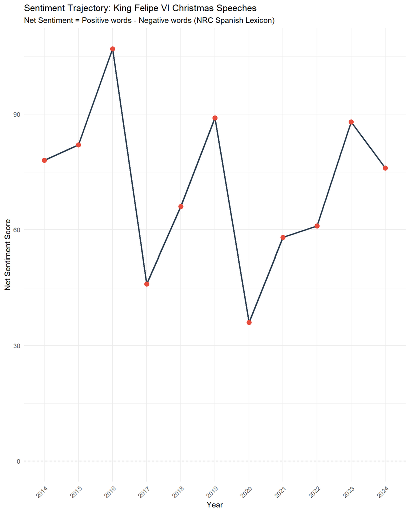

```r
# --- 1. VISUALIZING THE EMOTIONAL TRAJECTORY ---
# We plot the Net Sentiment over time to identify "Highs" and "Lows"
# in the King's 10-year Christmas address history.

ggplot(sentiment_by_year, aes(x = factor(year), y = net_sentiment, group = 1)) +
  # Main Trend Line: Representing the 'Flow' of the decade
  geom_line(color = "#2c3e50", linewidth = 1) +
  # Highlight Points: Marking each specific speech for clarity
  geom_point(color = "#e74c3c", size = 3) +
  # Baseline (Zero): Anything above this line is "Net Positive"
  geom_hline(yintercept = 0, linetype = "dashed", color = "grey50") +
  # Labels and Titles for a professional English report
  labs(title = "Sentiment Trajectory: King Felipe VI Christmas Speeches",
       subtitle = "Net Sentiment = Positive words - Negative words (NRC Spanish Lexicon)",
       x = "Year",
       y = "Net Sentiment Score") +
  # Clean theme for institutional analysis
  theme_minimal() +
  # Rotate X-axis labels for better readability during knitting
  theme(axis.text.x = element_text(angle = 45, hjust = 1))
```

In what is more, to complement the net sentiment view, the following grouped bar chart shows the absolute counts of positive and negative words per year. This helps distinguish between years where the net sentiment is low because both positive and negative language are abundant (a balanced or complex speech) versus years where one polarity clearly dominates.

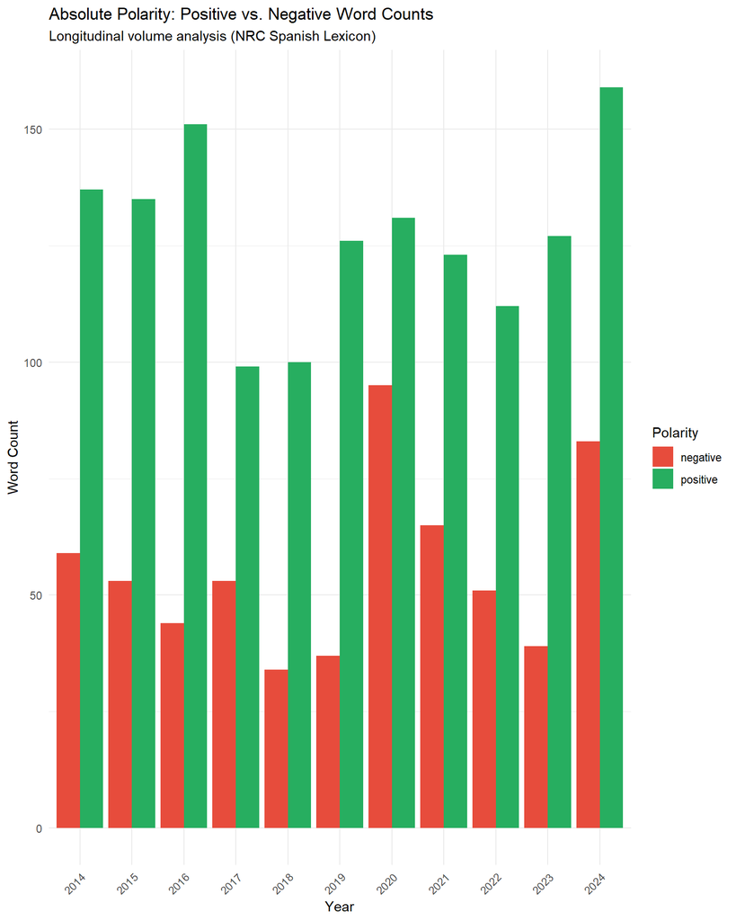

```r
# --- 1. COMPARATIVE POLARITY ANALYSIS ---
# This visualization breaks down the raw volume of positive vs. negative terms.
# Using 'position = dodge' allows for a direct year-by-year side comparison.

tidy_speeches %>%
  # Filter for emotional terms using the NRC polarity dictionary
  inner_join(nrc_polarity, by = "word") %>%
  # Extract the 4-digit Year from our paragraph tracking ID
  mutate(year = as.numeric(str_extract(paragraph_id, "^\\d{4}"))) %>%
  # Aggregate counts per Year and Sentiment category
  count(year, sentiment) %>%
  # Create the grouped bar chart
  ggplot(aes(x = factor(year), y = n, fill = sentiment)) +
  geom_col(position = "dodge") +
  # Use specific institutional colors (Green for Positive, Red for Negative)
  scale_fill_manual(values = c("negative" = "#e74c3c", "positive" = "#27ae60"),
                    name = "Polarity") +
  # English labels for the final report
  labs(title = "Absolute Polarity: Positive vs. Negative Word Counts",
       subtitle = "Longitudinal volume analysis (NRC Spanish Lexicon)",
       x = "Year",
       y = "Word Count") +
  theme_minimal() +
  # Rotate labels for better fit in the RMarkdown output
  theme(axis.text.x = element_text(angle = 45, hjust = 1))
```

Moreover, it is not only interesting to know the count, but also to inspect what are the leading words over the positive and negative categories, or the driving words within each sentiment. Because of that, and as demonstrated in the course materials with the Bing lexicon, identifying the words that contribute most to each polarity is essential to understand what drives the sentiment scores. A word like “crisis” classified as negative may appear frequently across many years simply because it is a recurring political term, inflating the negative count without necessarily reflecting a pessimistic tone. Similarly, checking for potential misclassifications is important: a word that the NRC lexicon labels as negative may carry a neutral or even positive connotation in the context of formal political discourse.

```r
# --- 1. WORD-LEVEL SENTIMENT CONTRIBUTION ---
# Identifying which specific terms are the primary drivers of our sentiment scores.
# This ensures that our findings are based on meaningful discourse, not noise.

word_sentiment_counts <- tidy_speeches %>%
  # Filter only for words with a recognized NRC polarity
  inner_join(nrc_polarity, by = "word") %>%
  # Count the occurrence of each emotional word across the whole corpus
  count(word, sentiment, sort = TRUE)
```

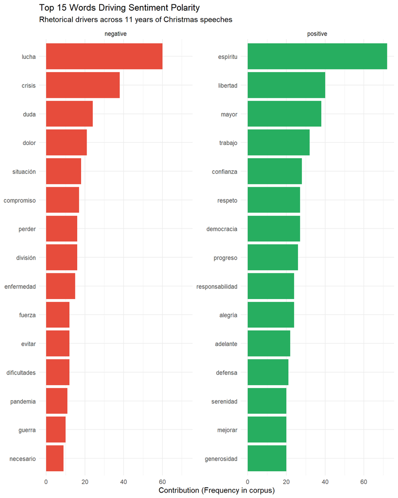

```r
# --- 2. TOP CONTRIBUTOR VISUALIZATION ---
# We split the view into 'Positive' and 'Negative' facets to see the top 15 drivers of each.

word_sentiment_counts %>%
  group_by(sentiment) %>%
  # Select the top 15 words per polarity group
  slice_max(n, n = 15) %>%
  ungroup() %>%
  # Reorder within the facet for a clean descending bar chart
  mutate(word = reorder_within(word, n, sentiment)) %>%
  ggplot(aes(x = n, y = word, fill = sentiment)) +
  geom_col(show.legend = FALSE) +
  # Create separate plots for positive and negative
  facet_wrap(~sentiment, scales = "free_y") +
  # Use tidytext's reordered scale for correctly sorted labels
  scale_y_reordered() +
  scale_fill_manual(values = c("negative" = "#e74c3c", "positive" = "#27ae60")) +
  # English titles for the final project report
  labs(title = "Top 15 Words Driving Sentiment Polarity",
       subtitle = "Rhetorical drivers across 11 years of Christmas speeches",
       x = "Contribution (Frequency in corpus)",
       y = NULL) +
  theme_minimal()
```

After looking at the graph, the most notable finding is that “lucha” (struggle/fight) dominates the negative polarity, yet in Spanish political rhetoric it frequently carries a positive connotation (e.g., “lucha por la igualdad”, “lucha contra la pandemia”). Similarly, “compromiso” (commitment) and “fuerza” (strength) are classified as negative despite being used in an overwhelmingly positive sense in this corpus. These cases will be examined in the following section. On the other hand, “espíritu” (will) and freedom (libertad) lead the positive side of the lexicon.

Because of this circumstance, it is important to assess whether any of them are misclassified in the context of royal political speeches. As seen in the previous chart, words like “lucha” (fight/struggle), “compromiso” (commitment), “fuerza” (strength) and “situación” (situation) are classified as negative by the NRC lexicon, yet they frequently carry a neutral or positive connotation in Spanish political discourse (e.g., “lucha por la igualdad”, “compromiso con los ciudadanos”). These contextual mismatches are an inherent limitation of dictionary-based sentiment analysis, as noted by Isasi (2021), and should be taken into account when interpreting the results.

```r
# --- 1. FINAL QUALITY CONTROL: TOP 10 EMOTIONAL DRIVERS ---
# Manual inspection of the top terms to ensure rhetorical relevance.
# This table is used to validate the 'Sentiment Trajectory' results.

word_sentiment_inspection <- word_sentiment_counts %>%
  group_by(sentiment) %>%
  # Isolate the top 10 words for each polarity
  slice_max(n, n = 10) %>%
  ungroup() %>%
  # Select and clean the view for the final report
  select(word, sentiment, n)

# --- 2. DISPLAY TABLE ---
# Using 'knitr::kable' for a professional look in the final PDF/HTML output.
knitr::kable(word_sentiment_inspection,
             caption = "Top 10 Emotional Drivers by Polarity (Manual Validation)")
```

Top 10 Emotional Drivers by Polarity (Manual Validation)

| word | sentiment | n |
| --- | --- | --- |
| lucha | negative | 60 |
| crisis | negative | 38 |
| duda | negative | 24 |
| dolor | negative | 21 |
| situación | negative | 18 |
| compromiso | negative | 17 |
| división | negative | 16 |
| perder | negative | 16 |
| enfermedad | negative | 15 |
| dificultades | negative | 12 |
| evitar | negative | 12 |
| fuerza | negative | 12 |
| espíritu | positive | 72 |
| libertad | positive | 40 |
| mayor | positive | 38 |
| trabajo | positive | 32 |
| confianza | positive | 28 |
| democracia | positive | 27 |
| respeto | positive | 27 |
| progreso | positive | 26 |
| alegría | positive | 24 |
| responsabilidad | positive | 24 |

As it is easily viewable, while some words are of clear negative nuance, such as crisis, or pain, some others are of difficult correct matching because of the need of context and possible double meanings, such as fight. Given all mentioned, a wordcloud over positive and negative words is presented, to make it more graphically identifiable the previous paragraphs.

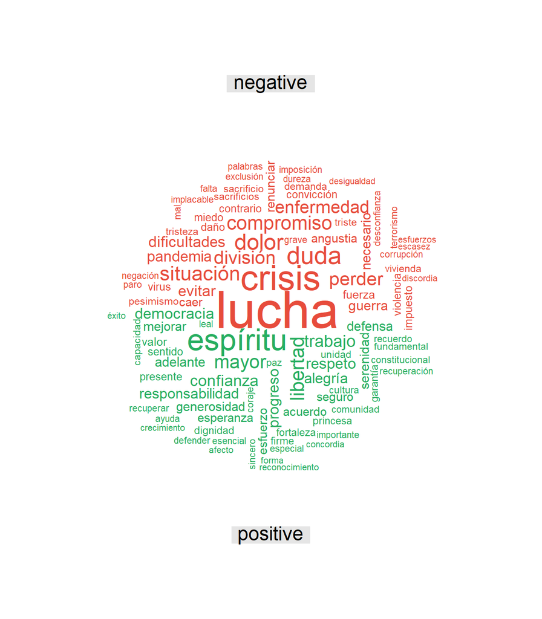

```r
# --- 1. REQUIRED LIBRARIES ---
# We load 'wordcloud' for the visualization and 'reshape2' for matrix transformation.
library(wordcloud)
library(reshape2)

# --- 2. CONSTRUCTING THE WORD-SENTIMENT MATRIX ---
# comparison.cloud requires a matrix where columns are the groups (sentiments)
# and rows are the words.
word_matrix <- tidy_speeches %>%
  inner_join(nrc_polarity, by = "word") %>%
  count(word, sentiment, sort = TRUE) %>%
  # acast transforms the tidy data into a matrix format
  reshape2::acast(word ~ sentiment, value.var = "n", fill = 0)

# --- 3. GENERATING THE COMPARISON CLOUD ---
# This visual contrasts the two polarities: Red (Challenges) vs. Green (Values).
set.seed(123) # Ensures the cloud layout is the same every time you knit

comparison.cloud(word_matrix,
                 colors = c("#e74c3c", "#27ae60"),
                 max.words = 100,
                 title.size = 1.5,
                 random.order = FALSE)
```

Moreover, not taking advantage of the sentiment-based aspect of the NRC lexicon would be a missed opportunity. By being based on Plutchik´s emotions, the lexicon offers enough granularity to be of special utility when analyzing political discourses where a speech may be simultaneously hopeful (anticipation, joy) and cautionary (fear, sadness), producing a net polarity close to zero that would mask important emotional nuance. Because of that, an analysis over the whole corpus is run in the following chunk.

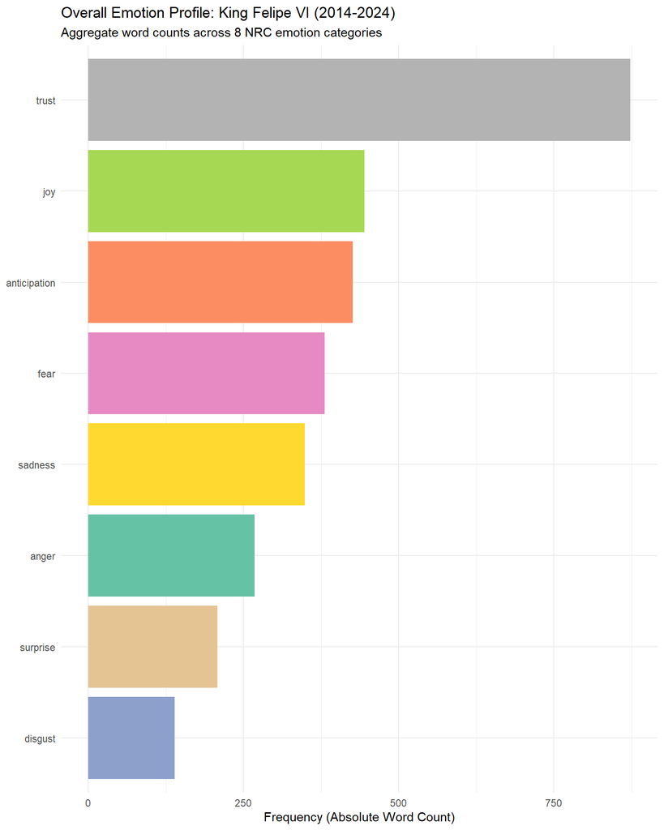

```r
# --- 1. ISOLATING SPECIFIC EMOTIONS ---
# We exclude the general 'positive' and 'negative' polarities to focus
# on the 8 core emotions: Anger, Anticipation, Disgust, Fear, Joy, Sadness, Surprise, Trust.

nrc_emotions <- nrc_es %>%
  filter(!sentiment %in% c("positive", "negative"))

# --- 2. AGGREGATING THE CORPUS EMOTION PROFILE ---
# This calculates the total emotional "footprint" of the King's 11-year tenure.

emotion_overall <- tidy_speeches %>%
  inner_join(nrc_emotions, by = "word") %>%
  count(sentiment, sort = TRUE)

# --- 3. VISUALIZING THE EMOTIONAL HIERARCHY ---
# A flipped bar chart is the most readable way to rank these emotions.

ggplot(emotion_overall, aes(x = reorder(sentiment, n), y = n, fill = sentiment)) +
  geom_col(show.legend = FALSE) +
  # Using coord_flip() to make the emotion labels easy to read
  coord_flip() +
  # Set2 is professional and distinct for categorical data
  scale_fill_brewer(palette = "Set2") +
  labs(title = "Overall Emotion Profile: King Felipe VI (2014-2024)",
       subtitle = "Aggregate word counts across 8 NRC emotion categories",
       x = NULL,
       y = "Frequency (Absolute Word Count)") +
  theme_minimal()
```

In what is more, it is interesting to see the evolution of these emotions through a decade of enormous changes. Because of that, the following heatmap visualises how the eight NRC emotions evolve across the 2014-2024 period. Rather than showing absolute counts, which would be affected by speech length, is needed to normalise by the total number of emotion-carrying words per year, producing proportions that are comparable across speeches of different lengths. This allows to observe shifts in the emotional composition of the discourse over time.

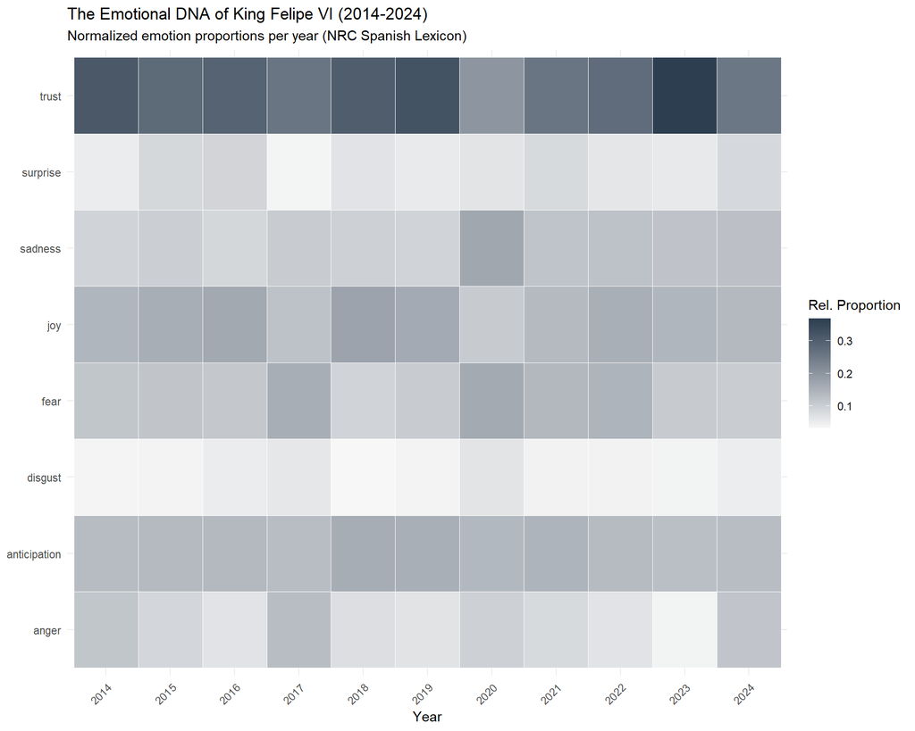

```r
# --- 1. NORMALIZING EMOTIONAL PROPORTIONS ---
# We calculate the relative weight of each emotion within its respective year.
# This prevents longer speeches from skewing the results.

emotion_by_year <- tidy_speeches %>%
  # Filter for the 8 core NRC emotions
  inner_join(nrc_emotions, by = "word") %>%
  # Extract year from ID
  mutate(year = as.numeric(str_extract(paragraph_id, "^\\d{4}"))) %>%
  # Aggregate counts
  count(year, sentiment) %>%
  # Calculate the percentage/proportion of each emotion per year
  group_by(year) %>%
  mutate(proportion = n / sum(n)) %>%
  ungroup()
# --- 2. EMOTIONAL HEATMAP VISUALIZATION ---
# Using geom_tile() creates a visual "DNA" of the King's addresses.
# Darker colors indicate a higher relative concentration of that emotion.

ggplot(emotion_by_year, aes(x = factor(year), y = sentiment, fill = proportion)) +
  geom_tile(color = "white") + # White borders for a clean "grid" look
  # Professional monochromatic scale
  scale_fill_gradient(low = "#f7f7f7", high = "#2c3e50", name = "Rel. Proportion") +
  labs(title = "The Emotional DNA of King Felipe VI (2014-2024)",
       subtitle = "Normalized emotion proportions per year (NRC Spanish Lexicon)",
       x = "Year",
       y = NULL) +
  theme_minimal() +
  # Rotate labels for clear reading in the final report
  theme(axis.text.x = element_text(angle = 45, hjust = 1))
```

In what is more, it is possible to build complementary visualizations to make this results even more rigorous and precise. Thus the following faceted line plot shows the evolution of each emotion individually, which makes it easier to track specific emotional trajectories that the heatmap compresses into a single colour scale.

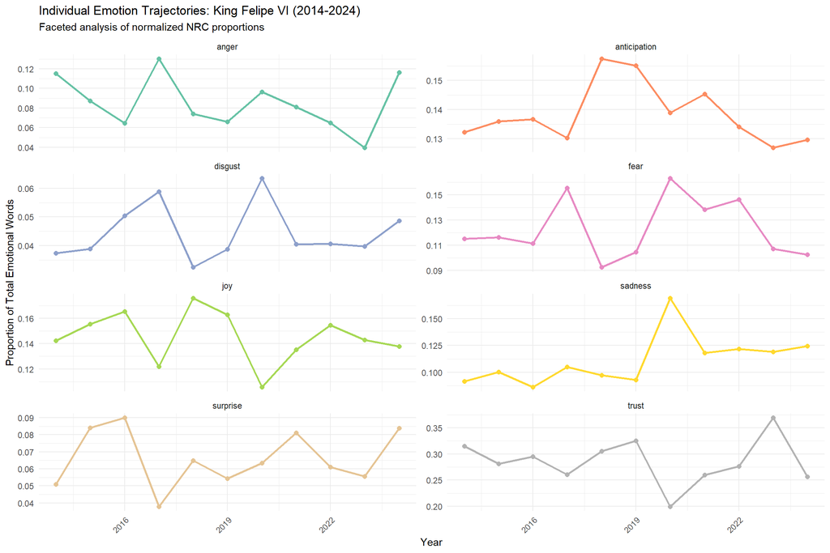

```r
# --- 1. LONGITUDINAL EMOTION TRAJECTORIES ---
# Faceting the 8 core emotions to identify specific historical correlations.
# Using 'free_y' ensures that even low-frequency emotions show their trends.

ggplot(emotion_by_year, aes(x = year, y = proportion, color = sentiment)) +
  # Continuous line to show the decade's evolution
  geom_line(linewidth = 1) +
  # Points to highlight each annual speech
  geom_point(size = 2) +
  # Separate panels for each emotion (2 columns for a balanced layout)
  facet_wrap(~sentiment, scales = "free_y", ncol = 2) +
  # Consistent color palette from the previous bar charts
  scale_color_brewer(palette = "Set2") +
  labs(title = "Individual Emotion Trajectories: King Felipe VI (2014-2024)",
       subtitle = "Faceted analysis of normalized NRC proportions",
       x = "Year",
       y = "Proportion of Total Emotional Words") +
  theme_minimal() +
  theme(legend.position = "none",
        # Rotate labels to prevent overlapping in the facet grid
        axis.text.x = element_text(angle = 45, hjust = 1))
```

In what is more, and as said, paragraphs entail a more comprehensive and contextually-adapted framework when analysing political discourses. To see the nature of the sentiment characterizing the paragraphs of this corpus, the proportion of negative words relative to the total word count is computed. This allows to identify the specific passages where the King’s discourse reaches its most negative or most positive tone, providing concrete textual evidence to contextualise the year-level trends observed above.

```r
# --- 1. PARAGRAPH-LEVEL EMOTION DENSITY ---
# We calculate the proportion of emotional words relative to the total length
# of each paragraph. This identifies the "peaks" and "valleys" of the discourse.

# A. Total word count per paragraph
wordcounts_par <- tidy_speeches %>%
  count(paragraph_id, name = "total_words")

# B. Negative word count per paragraph
neg_words_par <- tidy_speeches %>%
  inner_join(nrc_polarity %>% filter(sentiment == "negative"), by = "word") %>%
  count(paragraph_id, name = "neg_words")

# C. Positive word count per paragraph
pos_words_par <- tidy_speeches %>%
  inner_join(nrc_polarity %>% filter(sentiment == "positive"), by = "word") %>%
  count(paragraph_id, name = "pos_words")

# --- 2. DATA INTEGRATION & RATIO CALCULATION ---
# We merge these counts and filter out very short paragraphs (under 10 words)
# to avoid "statistical noise" where a 3-word sentence might look 100% negative.

paragraph_sentiment <- wordcounts_par %>%
  left_join(neg_words_par, by = "paragraph_id") %>%
  left_join(pos_words_par, by = "paragraph_id") %>%
  mutate(
    neg_words = replace_na(neg_words, 0),
    pos_words = replace_na(pos_words, 0),
    neg_ratio = neg_words / total_words,
    pos_ratio = pos_words / total_words,
    year = as.numeric(str_extract(paragraph_id, "^\\d{4}"))
  ) %>%
  filter(total_words >= 10)

# --- 3. IDENTIFYING THE "EXTREMES" ---
# Top 5 most negative paragraphs (The "Crisis" moments)
most_negative <- paragraph_sentiment %>%
  slice_max(neg_ratio, n = 5) %>%
  select(paragraph_id, year, total_words, neg_words, neg_ratio)

# Top 5 most positive paragraphs (The "Values/Hope" moments)
most_positive <- paragraph_sentiment %>%
  slice_max(pos_ratio, n = 5) %>%
  select(paragraph_id, year, total_words, pos_words, pos_ratio)

# Displaying results for the final report
print("TOP 5 MOST NEGATIVE PARAGRAPHS:")
```

```
## [1] "TOP 5 MOST NEGATIVE PARAGRAPHS:"
```

```r
print(most_negative)
```

```
## # A tibble: 5 × 5
##   paragraph_id  year total_words neg_words neg_ratio
##   <chr>        <dbl>       <int>     <int>     <dbl>
## 1 2020_par5     2020          27        14     0.519
## 2 2020_par9     2020          14         7     0.5
## 3 2021_par11    2021          10         4     0.4
## 4 2020_par8     2020          18         7     0.389
## 5 2015_par18    2015          19         7     0.368
```

```r
print("TOP 5 MOST POSITIVE PARAGRAPHS:")
```

```
## [1] "TOP 5 MOST POSITIVE PARAGRAPHS:"
```

```r
print(most_positive)
```

```
## # A tibble: 5 × 5
##   paragraph_id  year total_words pos_words pos_ratio
##   <chr>        <dbl>       <int>     <int>     <dbl>
## 1 2015_par20    2015          13         9     0.692
## 2 2021_par26    2021          14         9     0.643
## 3 2022_par25    2022          28        17     0.607
## 4 2019_par25    2019          20        12     0.6
## 5 2015_par28    2015          21        12     0.571
```

As it is shown, three of the five most negative paragraphs belong to the 2020 speech, with the most negative passage (2020_par5) reaching a 51.9% negative word ratio, reinforcing the pandemic year as the emotional low point of the corpus. Conversely, the most positive paragraphs tend to appear towards the end of the speeches (par20, par25, par26 and par28), suggesting a consistent rhetorical pattern where the King closes with an optimistic, forward-looking message.

Once identified the most positive and negative paragraphs of the whole corpus, it is both needed and of great interest to inspect them to see which specific words make them the most extreme cases of positivity and negativity. Hence, and to verify that the lexicon-based classification aligns with the actual content, the full text of the most negative and most positive paragraphs is inspected under the follwoing logic: if the paragraphs flagged as extreme by the algorithm are genuinely negative or positive when read in context, we can have greater confidence in the overall results.

```r
# --- 1. QUALITATIVE VALIDATION: DISCOURSE INSPECTION ---
# We extract the full text for the most extreme paragraphs identified
# by our sentiment ratio model to verify the context of the results.

# A. Inspection: The "Negative" Peak
# Identifying the specific section where the King addressed the most severe challenges.
top_neg_id <- most_negative$paragraph_id[1]

cat("--- MOST NEGATIVE PARAGRAPH (ID:", top_neg_id, ") ---\n")
```

```
## --- MOST NEGATIVE PARAGRAPH (ID: 2020_par5 ) ---
```

```r
speeches_paragraphs %>%
  filter(paragraph_id == top_neg_id) %>%
  pull(paragraph) %>%
  cat()
```

```
## Muchos ciudadanos y familias vivís la angustia del desempleo o la precariedad; la angustia de apenas llegar a cubrir las necesidades básicas; o sentís la tristeza de tener que abandonar un negocio al que habéis dedicado vuestra vida. Por todo ello es lógico y comprensible que el desánimo o la des…
```

```r
cat("\n\n")
```

```r
# B. Inspection: The "Positive" Peak
# Identifying the specific section where the King expressed the highest values or optimism.
top_pos_id <- most_positive$paragraph_id[1]

cat("--- MOST POSITIVE PARAGRAPH (ID:", top_pos_id, ") ---\n")
```

```
## --- MOST POSITIVE PARAGRAPH (ID: 2015_par20 ) ---
```

```r
speeches_paragraphs %>%
  filter(paragraph_id == top_pos_id) %>%
  pull(paragraph) %>%
  cat()
```

```
## Por eso, esta noche quiero reiterar un mensaje de serenidad, de tranquilidad y confianza en la unidad y continuidad de España; un mensaje de seguridad en la primacía y defensa de nuestra Constitución.
```

The manual inspection confirms that the lexicon captures the emotional tone accurately in both cases. The most negative paragraph (2020_par5) describes citizens’ anguish over unemployment and economic precarity, with words like “angustia”, “desempleo”, “tristeza” and “desconfianza” clearly justifying its classification. The most positive paragraph (2015_par20) is an explicit appeal to serenity, trust and constitutional unity. This alignment between the algorithmic classification and a human reading of the text validates the reliability of the NRC lexicon for this corpus.

Lastly on this section, the net sentiment for each paragraph and plot it sequentially within each year is plotted. This reveals the internal narrative structure of each speech: whether the King opens with an acknowledgement of difficulties before pivoting to a message of hope, or whether the tone remains consistent throughout.

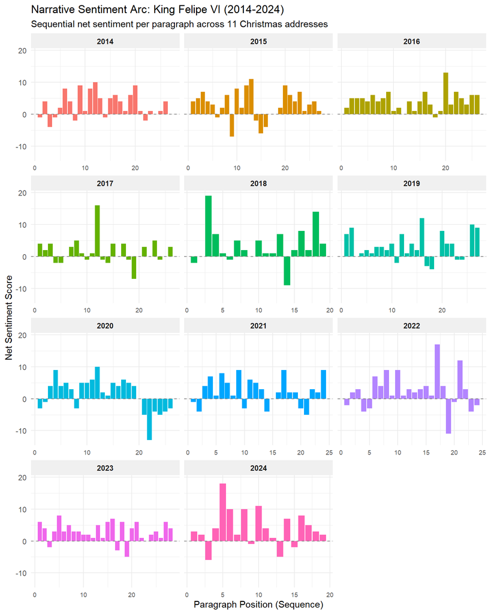

```r
# --- 1. MAPPING THE NARRATIVE ARC ---
# We calculate the net sentiment for every individual paragraph and
# track its sequential position (order) within each annual speech.

paragraph_net <- paragraph_sentiment %>%
  # Calculate the emotional balance per paragraph
  mutate(net_sentiment = pos_words - neg_words) %>%
  # Group by year to reset the 'paragraph counter' for each speech
  group_by(year) %>%
  mutate(paragraph_order = row_number()) %>%
  ungroup()

# --- 2. VISUALIZING THE "EMOTIONAL ROLLERCOASTER" ---
# Each facet represents one year, showing how the King moves
# from one emotion to the next during his 10-15 minute address.

ggplot(paragraph_net, aes(x = paragraph_order, y = net_sentiment, fill = factor(year))) +
  # Bar chart to show the "pulse" of the speech
  geom_col(show.legend = FALSE) +
  # Facet by year with free X-axes (since speech lengths vary)
  facet_wrap(~year, scales = "free_x", ncol = 3) +
  # Reference line at zero: bars below are "Problem areas," above are "Solution areas"
  geom_hline(yintercept = 0, linetype = "dashed", color = "grey50") +
  labs(title = "Narrative Sentiment Arc: King Felipe VI (2014-2024)",
       subtitle = "Sequential net sentiment per paragraph across 11 Christmas addresses",
       x = "Paragraph Position (Sequence)",
       y = "Net Sentiment Score") +
  theme_minimal() +
  # Small text for the X-axis to ensure paragraph numbers don't overlap
  theme(axis.text.x = element_text(size = 7),
        strip.background = element_rect(fill = "#f0f0f0", color = NA),
        strip.text = element_text(face = "bold"))
```

## 4 Topic Modelling on Felipe VI´s speeches.

Once data preparation and sentiment analysis are done, topic modelling both complements and nourishes the rigor of this analysis. In that light, the following chunks replicate the needed operations to perform this computational tool, meaning Latent Dirichlent Allocation (LDA), under the assumption of every speech being a mixture of topics and each of those topics being a mixture of words and the hope of being able to classify speeches by their predominant topic.

```r
# --- TOPIC MODELING PREPARATION (DTM CONVERSION) ---
# We transform the tidy text into a Document-Term Matrix (DTM).

# 1. Count and Filter
# We count word occurrences and remove "hapax legomena" (words appearing only once).
tidy_speeches_counts <- tidy_speeches %>%
  # Count how many times each word appears in each paragraph
  count(paragraph_id, word) %>%
  # Group by word to see global frequency
  group_by(word) %>%
  # Keep only words that appear at least twice across the whole corpus
  filter(sum(n) >= 2) %>%
  ungroup()

# 2. Casting to DTM
# Rows: Paragraphs | Columns: Unique Words | Values: Counts
speeches_dtm <- tidy_speeches_counts %>%
  cast_dtm(paragraph_id, word, n)

# 3. Handling Sparsity/Empty Rows
# LDA will fail if a document has zero words. We remove any empty rows.
speeches_dtm <- speeches_dtm[slam::row_sums(speeches_dtm) > 0, ]

# 4. Final Inspection
print(speeches_dtm)
```

```
## <<DocumentTermMatrix (documents: 313, terms: 1118)>>
## Non-/sparse entries: 5518/344416
## Sparsity           : 98%
## Maximal term length: 19
## Weighting          : term frequency (tf)
```

Once DTM is built, it is easily visible how rich and diverse the lexicon used across the corpus. With a sparsity of 98%, the vast majority of words used are not repeated, which might be an indicator of the institutional tone and wording of a political speech. Hence, the resulting DTM contains 313 documents and more than a thousand terms, which overall tend to indicate that topic modelling can be run and is expected to offer interesting results.

However, for topic modelling is crucial to choose the number of topics to try, which is not an easy task as by definition, topic modelling is an unsupervised machine learning tool. To overcome this difficulty, and to determine the optimal number of topics, the `ldatuning` package is used, which fits multiple LDA models across a range of K values and evaluates each using established metrics. We test values from K=2 to K=10, using two metrics: CaoJuan2009, which should be minimized, and Deveaud2014, which should be maximized. The K value where both metrics converge towards their respective optimal values is selected as the most appropriate number of topics.

```r
# --- 0. INSTALLATION & LOAD ---
# Only run the install lines once. Rtools must be installed on your PC first!
# if (!require("devtools")) install.packages("devtools")
# devtools::install_github("nikita-moor/ldatuning")

library(ldatuning)
library(topicmodels)

# --- 1. FINDING THE OPTIMAL K ---
# We evaluate metrics across 2 to 10 topics to find the mathematical 'sweet spot'.
# Note: This may take a minute or two depending on your CPU.

result <- FindTopicsNumber(
  speeches_dtm,
  topics = seq(from = 2, to = 10, by = 1),
  metrics = c("CaoJuan2009", "Deveaud2014"),
  method = "Gibbs",
  control = list(seed = 1234),
  verbose = TRUE
)
```

```
## fit models... done.
## calculate metrics:
##   CaoJuan2009... done.
##   Deveaud2014... done.
```

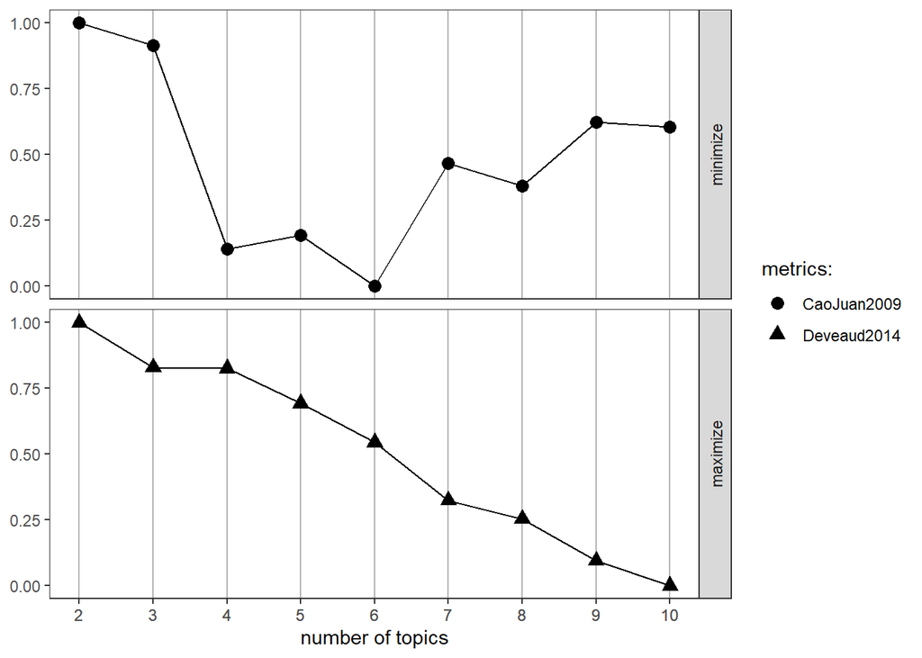

```r
# --- 2. VISUALIZATION ---
# Look for where CaoJuan is at its lowest (valley)
# and Deveaud is at its highest (peak).
FindTopicsNumber_plot(result)
```

```r
# --- TOPIC MODELING: EXECUTION & VISUALIZATION ---

# 1. Run the Latent Dirichlet Allocation (LDA) model
# We use k=4 topics, the Gibbs sampling method, and a seed for reproducibility.
speeches_lda <- LDA(speeches_dtm,
                    k = 4,
                    method = "Gibbs",
                    control = list(seed = 1234, iter = 500))

# Display model summary
speeches_lda
```

```
## A LDA_Gibbs topic model with 4 topics.
```

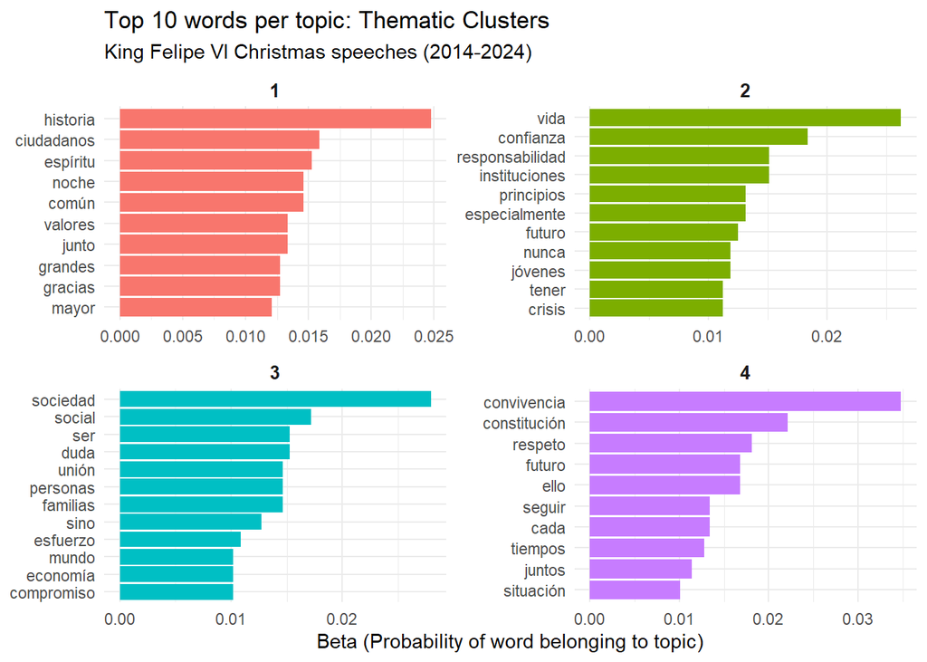

```r
# 2. Extract 'Beta' (Word-Topic Probabilities)
# This identifies which words are most representative of each topic.
speech_topics <- tidy(speeches_lda, matrix = "beta")

# 3. Visualize Top 10 Words per Topic
# We filter for the top terms and use reorder_within for a clean faceted plot.
speech_topics %>%
  group_by(topic) %>%
  slice_max(beta, n = 10) %>%
  ungroup() %>%
  mutate(term = reorder_within(term, beta, topic)) %>%
  ggplot(aes(beta, term, fill = factor(topic))) +
  geom_col(show.legend = FALSE) +
  facet_wrap(~ topic, scales = "free") +
  scale_y_reordered() +
  labs(title = "Top 10 words per topic: Thematic Clusters",
       subtitle = "King Felipe VI Christmas speeches (2014-2024)",
       x = "Beta (Probability of word belonging to topic)",
       y = NULL) +
  theme_minimal() +
  theme(strip.text = element_text(face = "bold", size = 10))
```

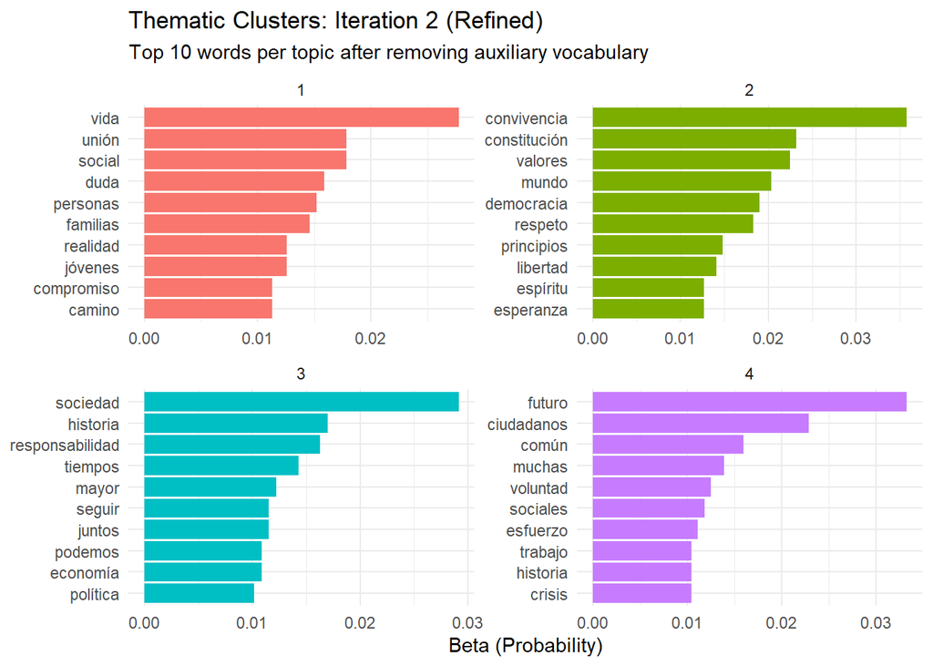

```r
# --- TOPIC MODELING: ITERATION 2 (CONTENT REFINEMENT) ---

# 1. Expand Custom Stopwords
# We add high-frequency functional words that were crowding the first model.
custom_stops_v2 <- data.frame(word = c(
  custom_stops$word, # Includes your original list
  "sino", "largo", "junto", "cada", "grandes",
  "siempre", "ser", "nunca", "especialmente",
  "noche", "gracias", "tener", "mismos", "ello",
  "mejor"
))

# 2. Re-Tokenize and Clean
tidy_speeches_v2 <- speeches_paragraphs %>%
  unnest_tokens(word, paragraph) %>%
  anti_join(spanish_stops, by = "word") %>%
  anti_join(custom_stops_v2, by = "word") %>%
  # Note: count() creates the 'n' column needed for filtering
  count(paragraph_id, word, sort = TRUE)

# 3. Filter and Cast to DTM
# Keep words appearing at least twice and remove empty rows
tidy_speeches_filtered_v2 <- tidy_speeches_v2 %>%
  group_by(word) %>%
  filter(sum(n) >= 2) %>%
  ungroup()

speeches_dtm_v2 <- tidy_speeches_filtered_v2 %>%
  cast_dtm(paragraph_id, word, n)

speeches_dtm_v2 <- speeches_dtm_v2[slam::row_sums(speeches_dtm_v2) > 0, ]

# 4. Run Refined LDA (k = 4)
speeches_lda_v2 <- LDA(speeches_dtm_v2,
                        k = 4,
                        method = "Gibbs",
                        control = list(seed = 1234, iter = 500))

# 5. Visualize Refined Topics
tidy(speeches_lda_v2, matrix = "beta") %>%
  group_by(topic) %>%
  slice_max(beta, n = 10) %>%
  ungroup() %>%
  mutate(term = reorder_within(term, beta, topic)) %>%
  ggplot(aes(beta, term, fill = factor(topic))) +
  geom_col(show.legend = FALSE) +
  facet_wrap(~ topic, scales = "free") +
  scale_y_reordered() +
  labs(title = "Thematic Clusters: Iteration 2 (Refined)",
       subtitle = "Top 10 words per topic after removing auxiliary vocabulary",
       x = "Beta (Probability)", y = NULL) +
  theme_minimal()
```

*Topic 1: Social challenges and collective effort*

*Topic 2: Civic and constitutional values*

This is the most institutionally grounded topic, anchored by explicit references to the constitutional framework and the values associated with it. It reflects the King’s recurring appeal to civic coexistence and the rule of law.

*Topic 4: Future, generations and hope*

Finally, and in line with course materials, each paragraph can be assigned to its dominant topic based on the highest *gamma* value. The proportion of paragraphs assigned to each topic is then computed per year, allowing us to track how the thematic composition of the speeches shifts across the 2014-2024 period.

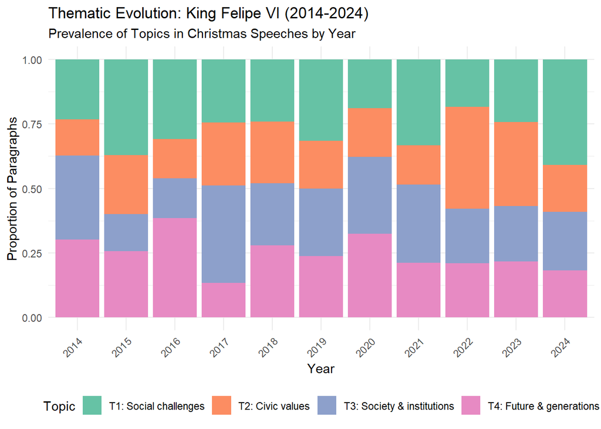

```r
# --- TOPIC EVOLUTION OVER TIME (GAMMA ANALYSIS) ---

# 1. Extract 'Gamma' (Document-Topic Probabilities)
# We also parse the Year from the 'document' (paragraph_id) string.
speech_gamma <- tidy(speeches_lda_v2, matrix = "gamma") %>%
  mutate(year = as.numeric(str_extract(document, "^\\d{4}")))

# 2. Identify the Dominant Topic per Paragraph
# We filter for the topic with the highest gamma for each paragraph,
# then calculate the proportion of each topic per year.
topic_by_year <- speech_gamma %>%
  group_by(document, year) %>%
  slice_max(gamma, n = 1) %>%
  ungroup() %>%
  count(year, topic) %>%
  group_by(year) %>%
  mutate(proportion = n / sum(n)) %>%
  ungroup() %>%
  # Labeling the topics based on your Iteration 2 interpretation
  mutate(topic = case_when(
    topic == 1 ~ "T1: Social challenges",
    topic == 2 ~ "T2: Civic values",
    topic == 3 ~ "T3: Society & institutions",
    topic == 4 ~ "T4: Future & generations"
  ))

# 3. Plot the Evolution
# This stacked bar chart shows the "thematic makeup" of each year's speech.
ggplot(topic_by_year, aes(x = factor(year), y = proportion, fill = topic)) +
  geom_bar(stat = "identity") +
  scale_fill_brewer(palette = "Set2", name = "Topic") +
  labs(title = "Thematic Evolution: King Felipe VI (2014-2024)",
       subtitle = "Prevalence of Topics in Christmas Speeches by Year",
       x = "Year", y = "Proportion of Paragraphs") +
  theme_minimal() +
  theme(axis.text.x = element_text(angle = 45, hjust = 1),
        legend.position = "bottom")
```

## 5 Conclusion.

In their findings, this words has been able to show how words, sentiments and topics have differed both in content and significance throughout time, often aligned in time with events of great importance such as pandemics, wars or political crisis. In what is more, it has provided sufficient evidence to further studies relying an Christmas speeches as a reliable source of information.

Notwithstanding, this study is still heavily dependant in some limitations, such as lexicon use biases and interpretative decisions such as the stopwoords list built. However and not minimizing what mentioned, this study is yet rigorous enough to worth both attention and replication.

That said, and oon the very and humble intention of having contributed to the academic debate born in class and academia, it ends.

## 6 Bibliography:

Isasi, J. (2021). Análisis de sentimientos en R con ‘syuzhet’. Programming Historian en español. https://doi.org/10.46430/phes0051

Mohammad, S. M., & Turney, P. D. (2013). Crowdsourcing a Word-Emotion Association Lexicon. *Computational Intelligence*, 29(3), 436-465.

Schweinberger, M. (2024). Topic modeling with R. The University of Queensland, School of Languages and Cultures. https://slcladal.github.io/topicmodels.html